# TWD - PD4

Bartek Sielicki

21 listopada 2018

## Praca Domowa nr 5

W ramach tej pracy domowej przeprowadziłem ankietę próbującą ukazać wpływ sposobu przedstawienia wykresu na jego interpretację. Ankieta składa się z dwóch części. Pierwsza przedstawia diagram kołowy, a zadaniem uczestnika jest odpowiedź na pytanie które miejsce w kolejności malejącej zajmuje dana zmienna. Druga część to wykres liniowy, przedstawiający wartość pewnej zmiennej w czasie.

Uczestnicy eksperymentu podzieleni zostali na dwie grupy. Obydwie dostały wykresy przedstawiające te same dane, jednak w różnej formie. Oczekiwanym celem badania było uzyskanie różnych rozkładów odpowiedzi od obu grup. Liczność pierwszej grupy wyniosła 8 osób, natomiast drugiej 9.

```r
# zbiór danych 1

label <- c("Ania", "Basia", "Janek", "Marek", "Tomek")
value <- c(36, 22, 20, 18, 4)
data1 <- data.frame(label, value)

# zbiór danych 2
year <- c(2000:2018)
price <- c(10.1, 9.9, 9.8, 10.0, 10.2, 10.1, 10.1, 10.3, 10.2, 10.5, 10.3, 10.6, 10.5, 10.6, 10.8, 10.8, 10.9, 11.0, 10.9)
data2 <- data.frame(year, price)
```

### Część 1 - diagram kołowy

Pytanie postawione było w ten sposób:

**Wykres kołowy przedstawia wyniki wyborów na przewodniczącego klasy. Które miejsce uzyskał Marek?**

#### Wykresy

**Grupa 1**

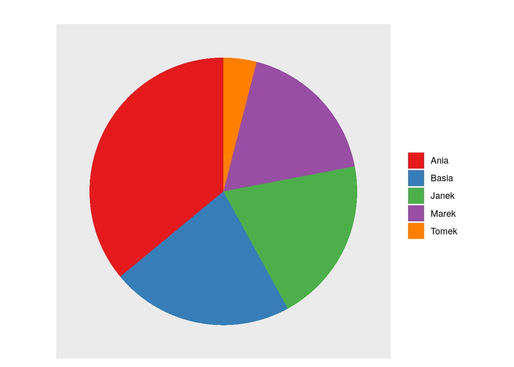

**Grupa 2**

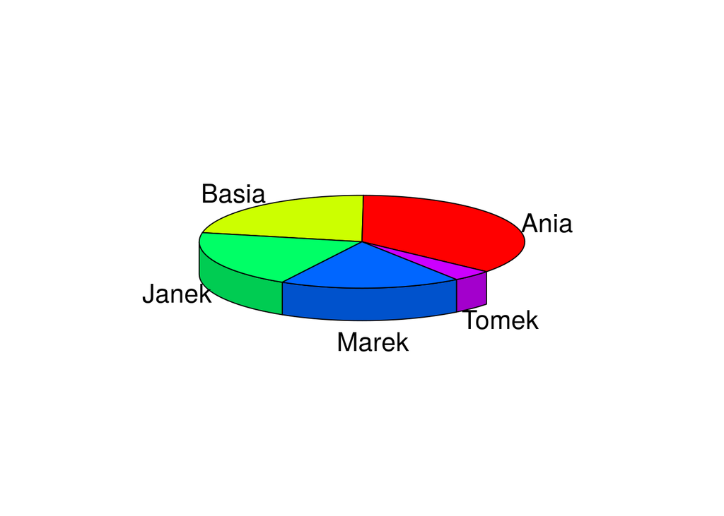

W grupie drugiej wykres został przedstawiony w trójwymiarze, z odpowiednio małego kąta, a także odpowiednio obrócony. Celem manipulacji, było wywarcie wrażenia, że Marek znalazł się nieco wyżej, niż na 4 miejscu. Dane liczbowe z oczywistych względów nie zostały na wykresie uwzględnione.

#### Wyniki

**Grupa 1**

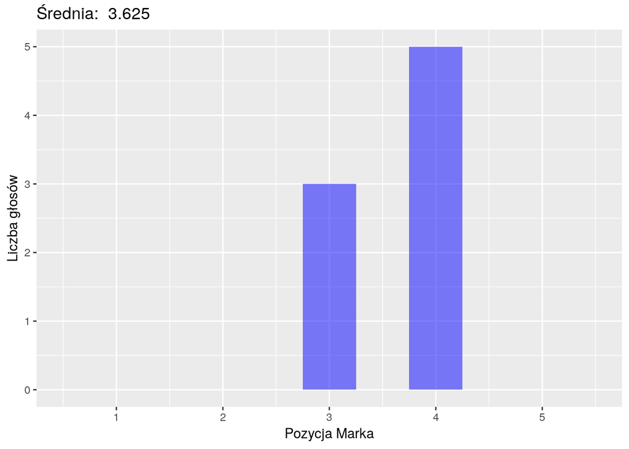

**Grupa 2**

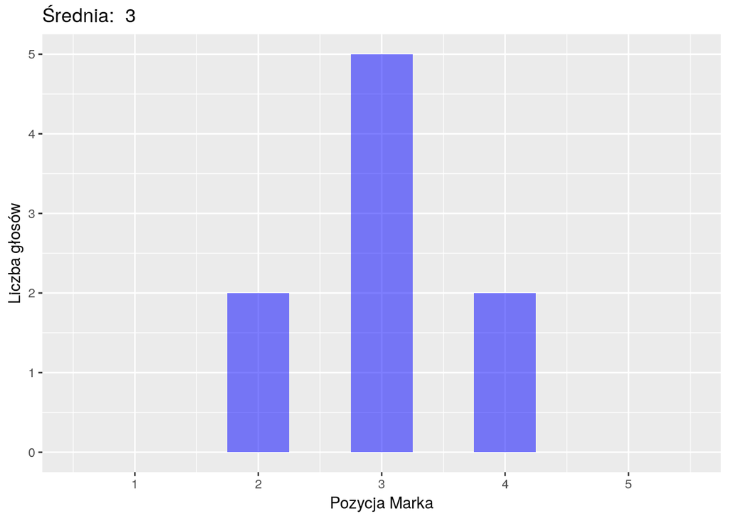

Jak widać, w grupie drugiej to pozycja nr 3 została najczęściej zaznaczaną odpowiedzią.

### Część druga - wykres liniowy

Pytanie postawione było w ten sposób:

**Wykres przedstawia cenę artykułu “X” na przedziale ostatnich 18 lat. Jak bardzo według Ciebie, w skali od 1 do 5, podrożał ten produkt?**

Wydawać się może ono dość infantylne, i na tyle subiektywne, że w zasadzie nie ma na nie prawidłowej odpowiedzi. Jednak to właśnie subiektywność, i sposób odbioru wykresu jest tutaj przedmiotem badań.

Wykresy przedstawione zostały tak:

**Grupa 1**

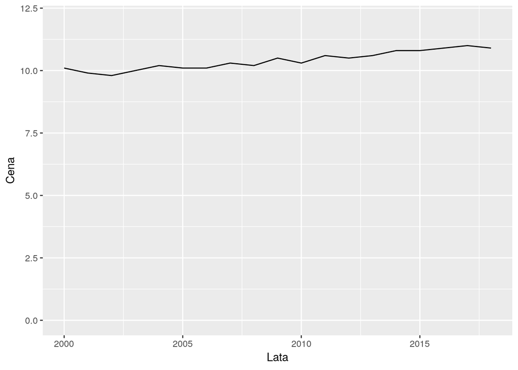

**Grupa 2**

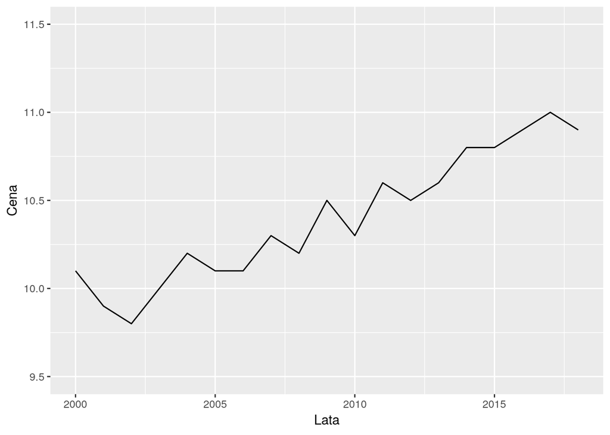

Różnica między nimi znajduje się oczywiście w doborze zakresu osi Y. Cel manipulacji również jest oczywisty - odbiorca wykresu powinien uznać że wzrost ceny produktu jest bardziej znaczący.

#### Wyniki

**Grupa 1**

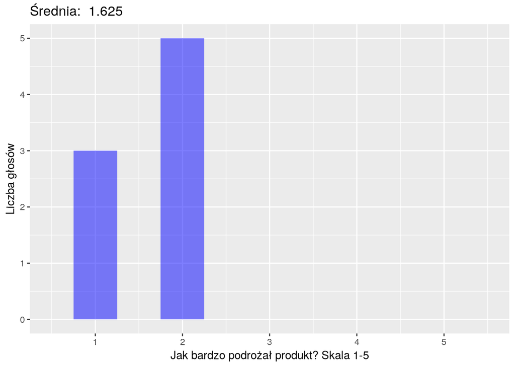

**Grupa 2**

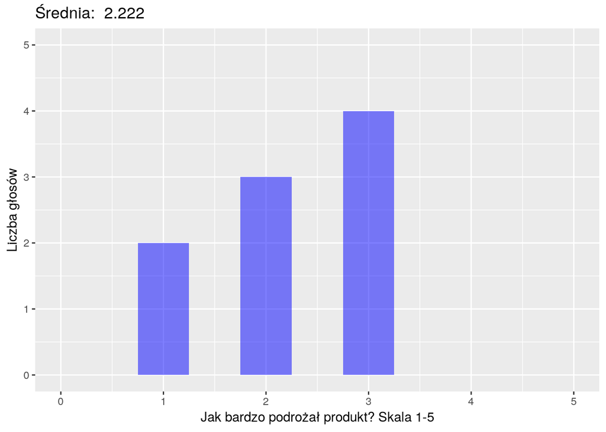

Wyniki ponownie są zauważalnie różne. W grupie pierwszej nie padła żadna odpowiedź 3 lub wyższa, podczas gdy w grupie drugiej odpowiedź 3 stała się już wartością dominującą.

Na tym etapie nie przeprowadzałem już bardziej szczegółowej analizy statystycznej, aby móc z określoną pewnością wyciągać wnioski dotyczące średnich czy rozkładu udzielanych odpowiedzi. Z pewnością byłby to jednak dobry kierunek w celu zbadania tego zagadnienia.